# 3.2 HW – Visualizations

Submission: Completed qmd file and rendered html file via Canvas.

## Overview

These problems apply the idea from the notes ‘3.2 – Visualizations’, where we learned how to create plots using in R using **ggplot2**.

We will be working with the `ggplot2::msleep` data ([documentation](https://ggplot2.tidyverse.org/reference/msleep.html)), which contains information on mammals sleep patterns as well as some categorical variables about the species. A subset is shown below:

| name | genus | vore | order | conservation | sleep_total | sleep_rem | sleep_cycle | awake | brainwt | bodywt |
| --- | --- | --- | --- | --- | --- | --- | --- | --- | --- | --- |
| Cheetah | Acinonyx | carni | Carnivora | lc | 12.1 | NA | NA | 11.9 | NA | 50.000 |
| Owl monkey | Aotus | omni | Primates | NA | 17.0 | 1.8 | NA | 7.0 | 0.01550 | 0.480 |
| Mountain beaver | Aplodontia | herbi | Rodentia | nt | 14.4 | 2.4 | NA | 9.6 | NA | 1.350 |
| Greater short-tailed shrew | Blarina | omni | Soricomorpha | lc | 14.9 | 2.3 | 0.1333333 | 9.1 | 0.00029 | 0.019 |
| Cow | Bos | herbi | Artiodactyla | domesticated | 4.0 | 0.7 | 0.6666667 | 20.0 | 0.42300 | 600.000 |
| Three-toed sloth | Bradypus | herbi | Pilosa | NA | 14.4 | 2.2 | 0.7666667 | 9.6 | NA | 3.850 |

## Assignment

The goal is to recreate several plots in order to get used to the different types of and the structure of ggplot2 function calls and how to customize plots. The following prompts will take you through a series of plots representing an exploratory data analysis (EDA) where each plot is sequentially updated to new plot types or to incorporate more variables, each time revealing more information.

### Part a – Bar graphs

Lets first investigate the sample sizes of different categories within the dataset. Recreate the following bar graph for type of `vore`.

Note this used the `ggplot2::theme_bw()` theme. To run a single command and set the theme for all the subsequent created plots, use `ggplot2::theme_set()` (check the documentation for more details).

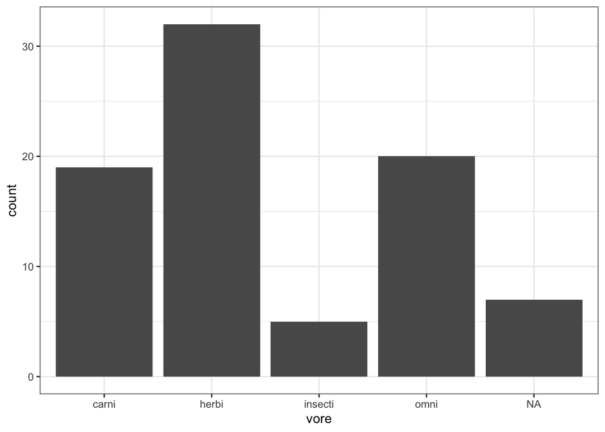

```r
# set global plot theme
theme_set(theme_bw())

# create a bar graph
ggplot(data = msleep) +
  geom_bar(aes(x = vore))
```

To make this plot more readable, a first step we could do is sort the bars according to decreasing frequency (when we do this, it is technically called a “Pareto chart”). To do so, replace `vore` with the following line of code in your `aes()` statement: `fct_infreq(vore)`. Check the help documentation of `forcats::fct_infreq()` to see what this function does.

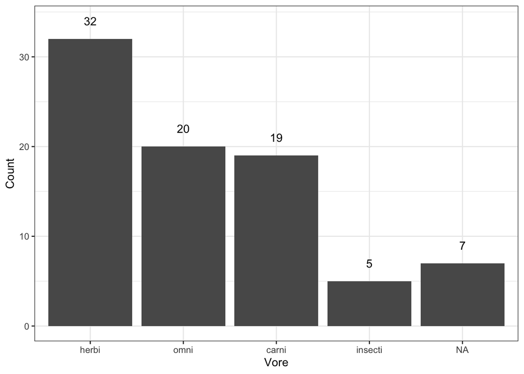

```r
# create a bar graph
# -> sorted by decreasing frequency
ggplot(data = msleep) +
  geom_bar(aes(x = fct_infreq(vore))) +
  stat_count(aes(x = vore,
                 y = after_stat(count) + 2,
                 label = after_stat(count)),
             geom ="text") +
  labs(x = "Vore",
       y = "Count")
```

We can also add the counts atop the bars just like adding data labels in Excel. To do this, add the following lines of code to the previous plot.

*Explanation of code:*

*- `geom_text(stat = "count", aes(x = vore, label = after_stat(count)))` counts the number of observations at each x `vore` value and uses the count as a label.*

*- Then it places the text label by default at the top of each bar, and `vjust = -1` moves the label one above the bar.*

Be sure to add nicer labels and title.

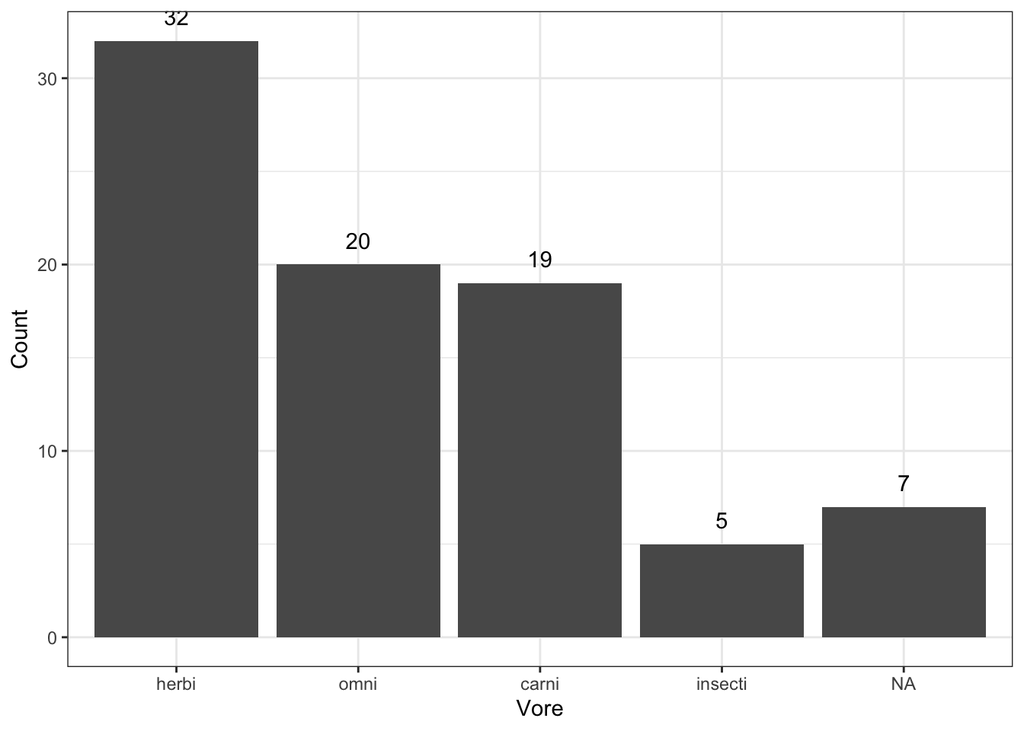

```r
# create a bar graph
# -> sorted by decreasing frequency
# -> add data labels
ggplot(data = msleep) +
  geom_bar(aes(x = fct_infreq(vore))) +
  geom_text(stat = "count",
            aes(x = vore,
                label = after_stat(count)),
            vjust = -1) +
  labs(x = "Vore",
       y = "Count")
```

### Part b – Histograms and density curves

Recreate the following histogram of `sleep_total`, paying attention to the changed aesthetics of the histogram.

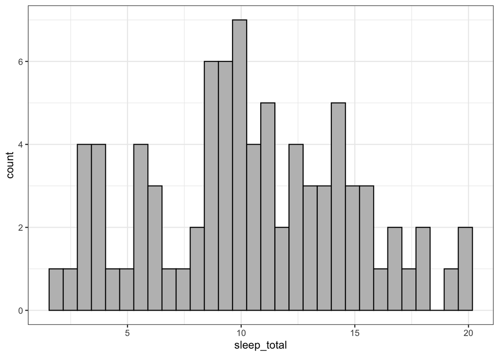

```r
# create histogram of single variable
ggplot(data = msleep) +
  geom_histogram(aes(x = sleep_total),
                 fill = "grey", color = "black")
```

Notice that this histogram by default is really choppy, lets change the `bins` argument to a smaller value to see how it looks. Try a few different values.

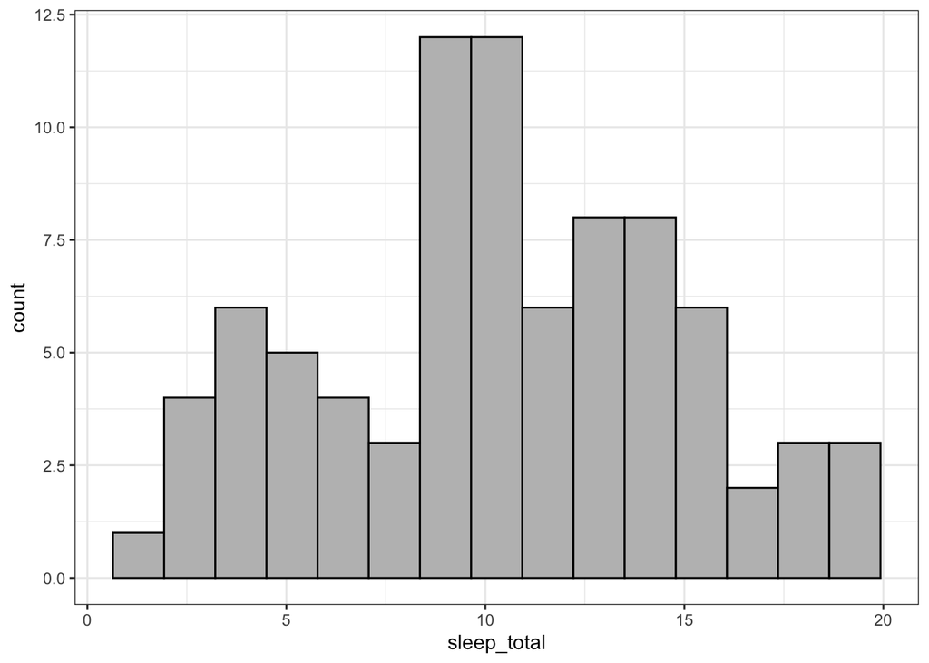

```r
# create histogram of single variable
ggplot(data = msleep) +
  geom_histogram(aes(x = sleep_total),
                 bins = 15,
                 fill = "grey", color = "black")
```

Perhaps a smooth curve would be a more accurate representation of this data than a histogram. Recreate the following density curve.

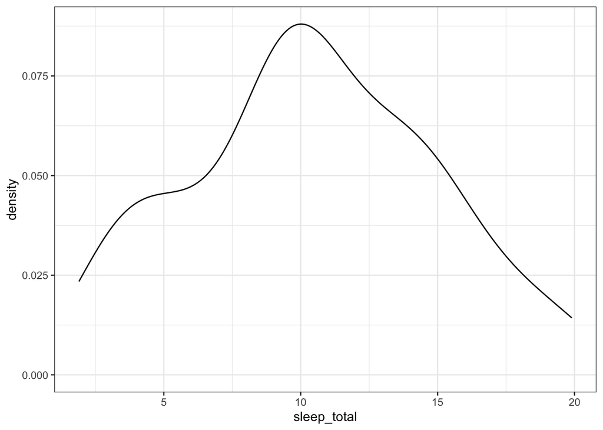

```r
# create histogram of single variable
ggplot(data = msleep) +
  geom_density(aes(x = sleep_total))
```

Lets add grouping information to the previous histogram to visualize `sleep_total` for each different type of `vore`. To do so, use the `fill = vore` to the `aes()` statement.

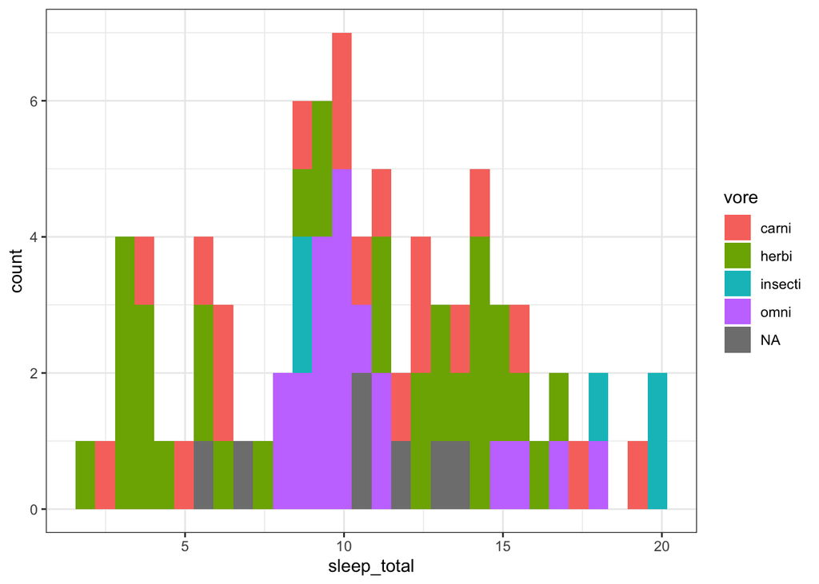

```r
# create histogram for grouping variable
ggplot(data = msleep) +
  geom_histogram(aes(x = sleep_total,
                     fill = vore))
```

It is nearly impossible to glean any information from this plot. So let’s switch to a density curve, which is better for displaying several distributions on the same plot. Recreate the following plot, pay attention to which aesthetic `vore` needs to be mapped to.

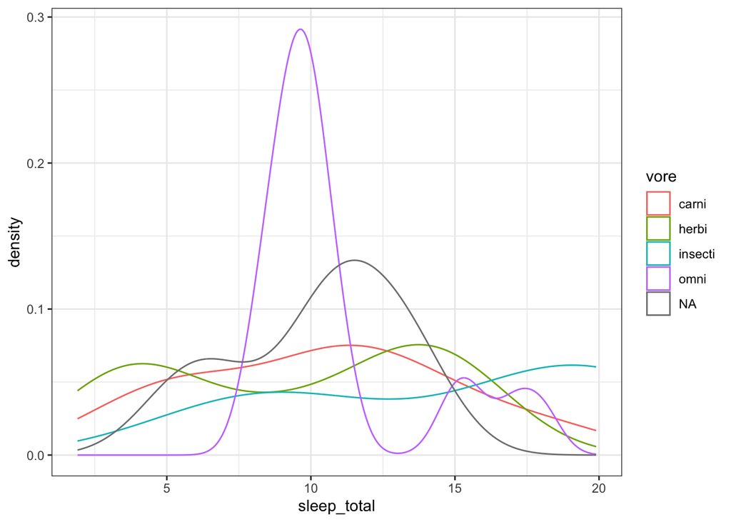

```r
# create histogram of single variable
ggplot(data = msleep) +
  geom_density(aes(x = sleep_total,
                   color = vore))
```

Now that we have a readable, accurate plot type for several distributions. Lets investigate more interesting quantities. Suppose we are interested in which animals have the biggest brains (proportionally). To study this we will visualize the ratio of brain weight to body weight based on the classification of animal vore. Recreate the following plot.

*HINTS:*

*- Remember we can do “algebra” with our variables within an `aes()` statement.*

*- To remove the `NA` category, we need to filter them out of the dataset used by `ggplot()`. We will learn how this function works in more detail next section, but for now replace `msleep` with the following code: `filter(msleep, !is.na(vore))`.*

*- Essentially, `is.na(vore)` evaluates to `TRUE` when there is a missing value of `NA` and `FALSE` when not missing, then `!` flips the logical so that `filter()` keeps only the non-missing values.*

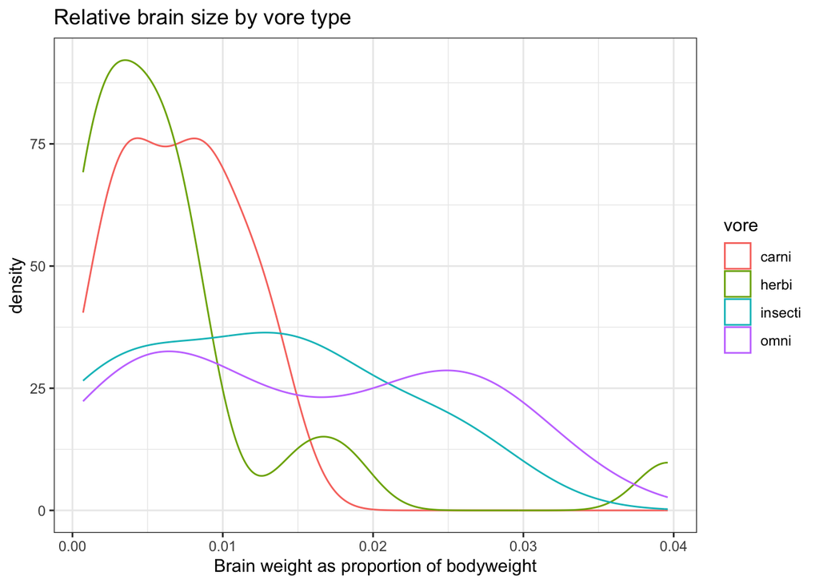

```r
# create histogram of single variable
g <- ggplot(data = filter(msleep, !is.na(vore))) +
  geom_density(aes(x = brainwt / bodywt,
                   color = vore))

# conditionally add nice labels if solutions are shown
if (solutions) {
  g +
    labs(title = "Relative brain size by vore type",
       x = "Brain weight as proportion of bodyweight")
} else {
  g +
    labs(title = "< insert nice title >",
         x = "< insert nice axis label >")
}
```

Be sure to add descriptive title and axis label. Write a sentence in your qmd file summarizing the relationships shown in the resulting plot.

### Part c – Comparative boxplots

An alternative to multiple density curves is comparative boxplots. Create horizontal comparative boxplots for `sleep_total` by `vore`.

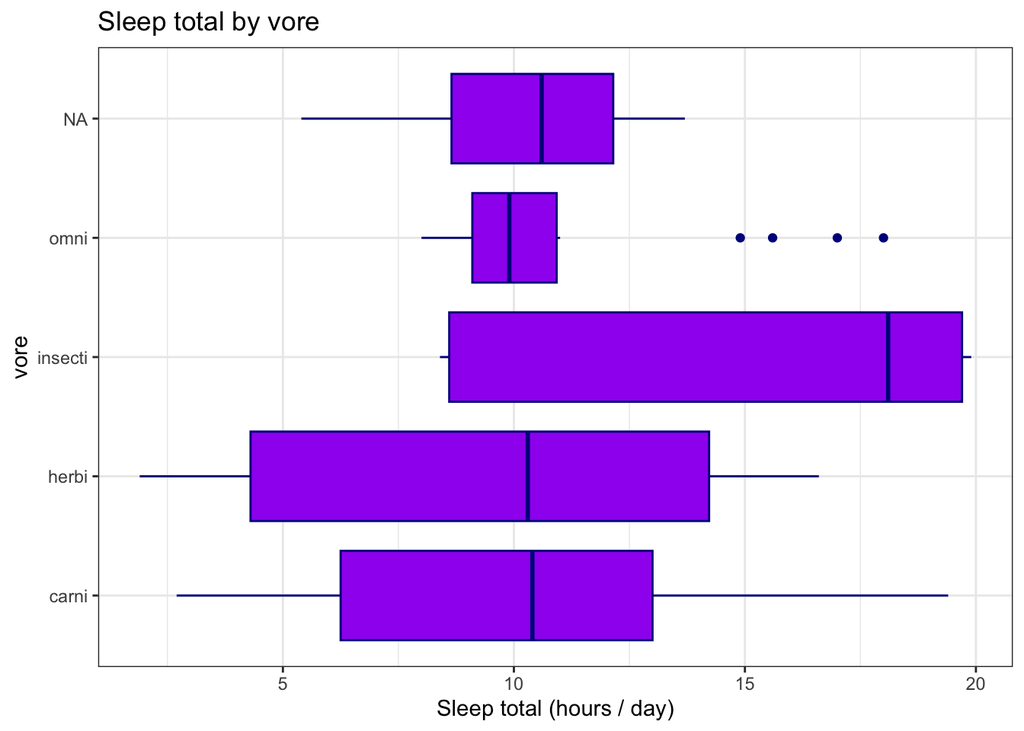

```r
# create comparative boxplots
ggplot(data = msleep) +
  geom_boxplot(aes(x = sleep_total,
                   y = vore),
               fill = "purple", color = "darkblue") +
  labs(title = "Sleep total by vore",
       x = "Sleep total (hours / day)")
```

Now convert this to a vertical comparative boxplots. Note that there are two ways this can be done. Be sure to add nice title and axis labels and change the overall color scheme of the boxplots to match the context of sleep. Write a sentence comparing the sleep totals for the different kind of vores.

### Part d – Scatterplots

Now we will visualize two quantitative variables. Recreate the following scatterplot, which investigates the hours of rem sleep compared to the total sleep hours.

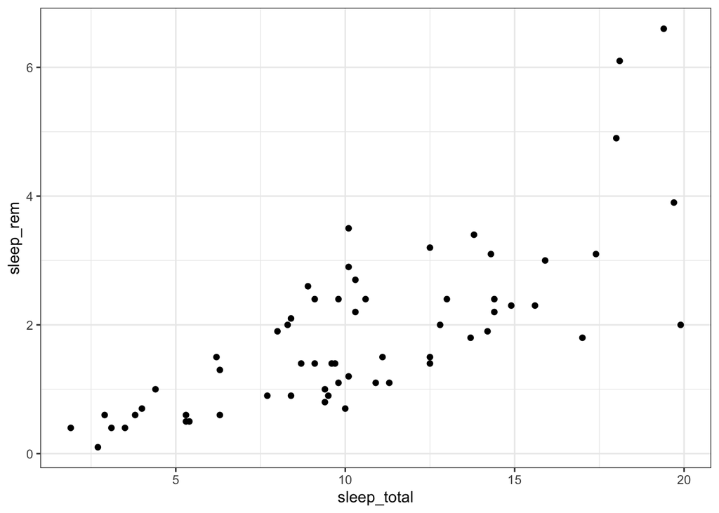

```r
# create scatterplot
ggplot(data = msleep) +
  geom_point(aes(x = sleep_total,
                 y = sleep_rem))
```

Try commenting out `method = "lm"` to see the effect. Then change `se = TRUE`.

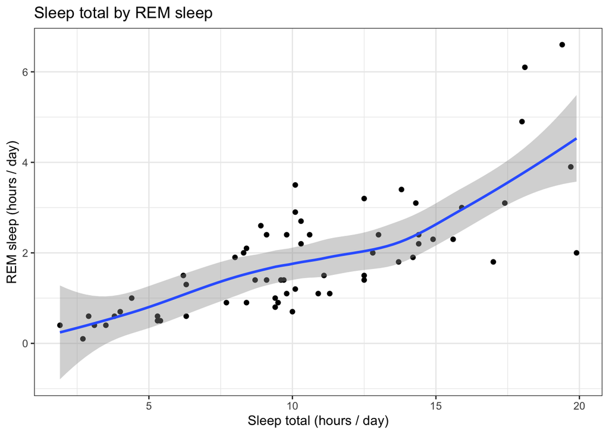

```r
# create scatterplot
ggplot(data = msleep) +
  geom_point(aes(x = sleep_total,
                 y = sleep_rem)) +
    geom_smooth(aes(x = sleep_total,
                  y = sleep_rem),
              se = TRUE) +
  labs(title = "Sleep total by REM sleep",
       x = "Sleep total (hours / day)",
       y = "REM sleep (hours / day)")
```

Be sure to add nice titles and axis labels.

Is it correct to model this relationship? REM sleep in hours per day is obviously a function of the sleep total; so there will implicitly be a relationship between these variables. To account for this, lets convert REM sleep to be relative to the total sleep hours by taking the ratio again like with brain weight and body weight. Create a new scatterplot with straight trend line for total sleep vs the ratio of REM sleep to total sleep.

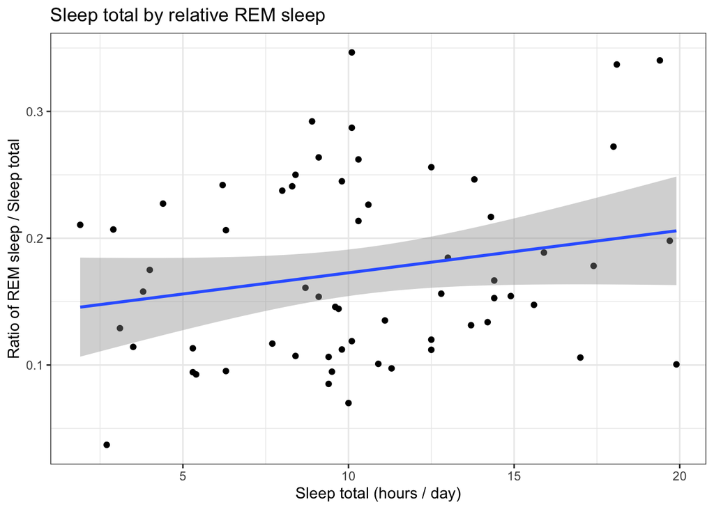

```r
# create scatterplot
# -> add straight line trend
ggplot(data = msleep) +
  geom_point(aes(x = sleep_total,
                 y = sleep_rem / sleep_total)) +
  geom_smooth(aes(x = sleep_total,
                  y = sleep_rem / sleep_total),
              method = "lm") +
  labs(title = "Sleep total by relative REM sleep",
       x = "Sleep total (hours / day)",
       y = "Ratio of REM sleep / Sleep total")
```

Write a sentence describing the relationship between relative REM sleep and the total amount of sleep based on the this and the previous plot.

### Part e – Visualize data

Create at least one additional polished plot visualizing relationships among variable(s). Include a sentence write-up detailing any conclusions drawn from the plot. Feel free to create more than one :)

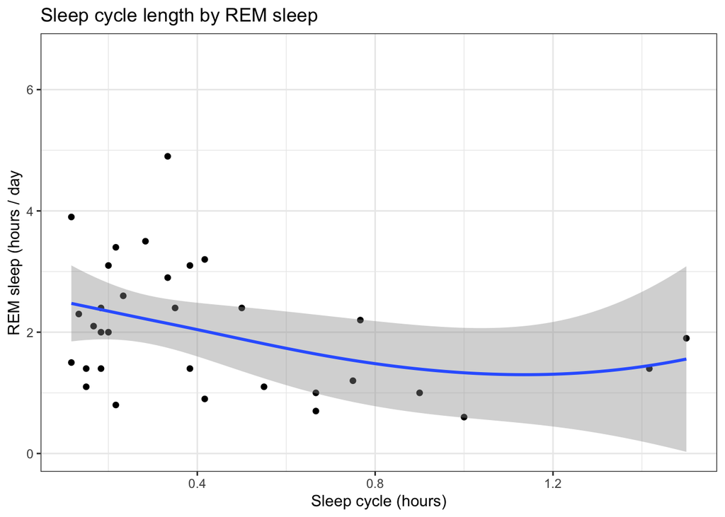

```r
# create scatterplot
ggplot(data = msleep) +
  geom_point(aes(x = sleep_cycle,
                 y = sleep_rem)) +
  geom_smooth(aes(x = sleep_cycle,
                  y = sleep_rem),
              span = 2) +
  labs(title = "Sleep cycle length by REM sleep",
       x = "Sleep cycle (hours)",
       y = "REM sleep (hours / day")
```

```r
# write-up: slight decreasing trend in REM sleep as length of sleep cycle increases
```